# Rothermel

The `Rothermel` module implements the [Rothermel (1972)](https://www.fs.usda.gov/research/treesearch/32533) surface fire spread model, the foundational model used by most US wildfire behavior systems (BehavePlus, FARSITE, ELMFIRE, etc.).

## How It Works

The model computes the **rate of spread** (m/min) of a surface fire given:

| Input | Description | Source |
| --- | --- | --- |
| **Fuel model** | Static fuel bed properties (loading, SAV ratio, heat content, depth, moisture of extinction) | `Rothermel` struct |
| **Moisture** | Fuel moisture content per size class | `FuelClasses` (keyword arg) |
| **Wind** | Midflame wind speed | Scalar (km/h) |
| **Slope** | Terrain slope as rise/run | Scalar (fraction) |

The fuel model is a **static landscape property** while moisture, wind, and slope are **dynamic environmental inputs** — matching how operational fire behavior systems separate these concerns.

## Types

### `FuelClasses`

A container for values across the five Rothermel fuel size classes.

```julia
FuelClasses{T}(; d1, d10, d100, herb, wood)
```

Values for the five Rothermel fuel size classes.

#### Fields

- `d1::T` - 1-hr dead fuel (< 0.25 in diameter)
- `d10::T` - 10-hr dead fuel (0.25–1.0 in)
- `d100::T` - 100-hr dead fuel (1.0–3.0 in)
- `herb::T` - Live herbaceous
- `wood::T` - Live woody

### `Rothermel`

The fuel model struct parameterized by the Rothermel (1972) equations.

```julia
Rothermel{T}(; name, w, σ, h, δ, Mx)
```

Fuel model for the Rothermel (1972) surface fire spread model.

Parameterized by numeric type `T` (e.g. `Float64`, `Float32`, Unitful quantities).

#### Fields (US customary units, matching original publications)

- `name::String` - Description
- `w::FuelClasses{T}` - Fuel loading [tons/acre]
- `σ::FuelClasses{T}` - Surface-area-to-volume ratio [1/ft]
- `h::FuelClasses{T}` - Heat content [BTU/lb]
- `δ::T` - Fuel bed depth [ft]
- `Mx::T` - Dead fuel moisture of extinction [fraction]

See `NFFL` for the 13 standard fuel models from Anderson (1982).

## NFFL Fuel Models

The 13 standard fuel models from [Anderson (1982)](https://www.fs.usda.gov/research/treesearch/6447) are provided as named constants:

| Constant | NFFL | Description | Depth (ft) | Mx |
| --- | --- | --- | --- | --- |
| `SHORT_GRASS` | 1 | Short grass (1 ft) | 1.0 | 0.12 |
| `TIMBER_GRASS` | 2 | Timber grass/understory | 1.0 | 0.15 |
| `TALL_GRASS` | 3 | Tall grass (2.5 ft) | 2.5 | 0.25 |
| `CHAPARRAL` | 4 | Chaparral (6 ft) | 6.0 | 0.20 |
| `BRUSH` | 5 | Brush (2 ft) | 2.0 | 0.20 |
| `DORMANT_BRUSH` | 6 | Dormant brush/hardwood slash | 2.5 | 0.25 |
| `SOUTHERN_ROUGH` | 7 | Southern rough | 2.5 | 0.40 |
| `CLOSED_TIMBER_LITTER` | 8 | Closed timber litter | 0.2 | 0.30 |
| `HARDWOOD_LITTER` | 9 | Hardwood litter | 0.2 | 0.25 |
| `TIMBER_UNDERSTORY` | 10 | Timber litter/understory | 1.0 | 0.25 |
| `LIGHT_SLASH` | 11 | Light logging slash | 1.0 | 0.15 |
| `MEDIUM_SLASH` | 12 | Medium logging slash | 2.3 | 0.20 |
| `HEAVY_SLASH` | 13 | Heavy logging slash | 3.0 | 0.25 |

```julia
SHORT_GRASS
```

```
Rothermel{Float64}("NFFL 1: Short grass (1 ft)")
```

## Scott & Burgan 40 Fuel Models

The 40 additional fuel models from [Scott and Burgan (2005)](https://www.fs.usda.gov/research/treesearch/9521) extend the original 13 NFFL models to cover a wider range of vegetation types. Together with the NFFL models, there are **53 standard fire behavior fuel models**.

The models are organized into six groups:

- **GR** (Grass): 9 models for grasslands, from sparse short grass to very high load humid climate grass
- **GS** (Grass-Shrub): 4 models for grass-shrub mixtures
- **SH** (Shrub): 9 models for shrublands, from low-load dry climate to very high load humid climate
- **TU** (Timber-Understory): 5 models for timber with understory fuels
- **TL** (Timber Litter): 9 models for timber litter, from compact conifer to very high load broadleaf
- **SB** (Slash-Blowdown): 4 models for logging slash and blowdown debris

**Tip**

Models marked **Dynamic** transfer live herbaceous fuel to the dead category based on curing level (determined by live herbaceous moisture). The fuel loads listed are *pre-transfer* values.

| Constant | Type | Description | Depth (ft) | Mx |
| --- | --- | --- | --- | --- |
| `GR1` | D | Short, sparse, dry climate grass | 0.4 | 0.15 |
| `GR2` | D | Low load, dry climate grass | 1.0 | 0.15 |
| `GR3` | D | Low load, very coarse, humid climate grass | 2.0 | 0.3 |
| `GR4` | D | Moderate load, dry climate grass | 2.0 | 0.15 |
| `GR5` | D | Low load, humid climate grass | 1.5 | 0.4 |
| `GR6` | D | Moderate load, humid climate grass | 1.5 | 0.4 |
| `GR7` | D | High load, dry climate grass | 3.0 | 0.15 |
| `GR8` | D | High load, very coarse, humid climate grass | 4.0 | 0.3 |
| `GR9` | D | Very high load, humid climate grass | 5.0 | 0.4 |
| `GS1` | D | Low load, dry climate grass-shrub | 0.9 | 0.15 |
| `GS2` | D | Moderate load, dry climate grass-shrub | 1.5 | 0.15 |
| `GS3` | D | Moderate load, humid climate grass-shrub | 1.8 | 0.4 |
| `GS4` | D | High load, humid climate grass-shrub | 2.1 | 0.4 |
| `SH1` | D | Low load, dry climate shrub | 1.0 | 0.15 |
| `SH2` | S | Moderate load, dry climate shrub | 1.0 | 0.15 |
| `SH3` | S | Moderate load, humid climate shrub | 2.4 | 0.4 |
| `SH4` | S | Low load, humid climate timber-shrub | 3.0 | 0.3 |
| `SH5` | S | High load, dry climate shrub | 6.0 | 0.15 |
| `SH6` | S | Low load, humid climate shrub | 2.0 | 0.3 |
| `SH7` | S | Very high load, dry climate shrub | 6.0 | 0.15 |
| `SH8` | S | High load, humid climate shrub | 3.0 | 0.4 |
| `SH9` | D | Very high load, humid climate shrub | 4.4 | 0.4 |
| `TU1` | D | Light load, dry climate timber-grass-shrub | 0.6 | 0.2 |
| `TU2` | S | Moderate load, humid climate timber-shrub | 1.0 | 0.3 |
| `TU3` | D | Moderate load, humid climate timber-grass-shrub | 1.3 | 0.3 |
| `TU4` | S | Dwarf conifer understory | 0.5 | 0.12 |
| `TU5` | S | Very high load, dry climate timber-shrub | 1.0 | 0.25 |
| `TL1` | S | Low load, compact conifer litter | 0.2 | 0.3 |
| `TL2` | S | Low broadleaf litter | 0.2 | 0.25 |
| `TL3` | S | Moderate load conifer litter | 0.3 | 0.2 |
| `TL4` | S | Small downed logs | 0.4 | 0.25 |
| `TL5` | S | High load conifer litter | 0.6 | 0.25 |
| `TL6` | S | Moderate load broadleaf litter | 0.3 | 0.25 |
| `TL7` | S | Large downed logs | 0.4 | 0.25 |
| `TL8` | S | Long-needle litter | 0.3 | 0.35 |
| `TL9` | S | Very high load broadleaf litter | 0.6 | 0.35 |
| `SB1` | S | Low activity fuel | 1.0 | 0.25 |
| `SB2` | S | Moderate activity fuel or low load blowdown | 1.0 | 0.25 |
| `SB3` | S | High activity fuel or moderate load blowdown | 1.2 | 0.25 |
| `SB4` | S | High load blowdown | 2.7 | 0.25 |

### Comparing SB40 Fuel Models

Rate of spread at a reference condition (wind = 8 km/h, slope = 0, live herbaceous moisture 60%, live woody moisture 90%):

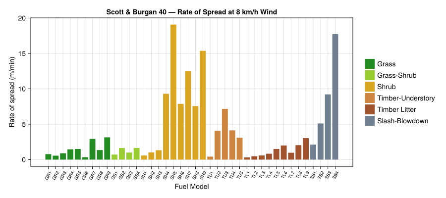

```julia
M_sb = FuelClasses(d1=0.06, d10=0.07, d100=0.08, herb=0.60, wood=0.90)

sb40_fuels = [
    GR1, GR2, GR3, GR4, GR5, GR6, GR7, GR8, GR9,
    GS1, GS2, GS3, GS4,
    SH1, SH2, SH3, SH4, SH5, SH6, SH7, SH8, SH9,
    TU1, TU2, TU3, TU4, TU5,
    TL1, TL2, TL3, TL4, TL5, TL6, TL7, TL8, TL9,
    SB1, SB2, SB3, SB4,
]
sb40_labels = [
    "GR1","GR2","GR3","GR4","GR5","GR6","GR7","GR8","GR9",
    "GS1","GS2","GS3","GS4",
    "SH1","SH2","SH3","SH4","SH5","SH6","SH7","SH8","SH9",
    "TU1","TU2","TU3","TU4","TU5",
    "TL1","TL2","TL3","TL4","TL5","TL6","TL7","TL8","TL9",
    "SB1","SB2","SB3","SB4",
]

sb_categories = vcat(
    fill("Grass", 9),
    fill("Grass-Shrub", 4),
    fill("Shrub", 9),
    fill("Timber-Understory", 5),
    fill("Timber Litter", 9),
    fill("Slash-Blowdown", 4),
)

sb_cat_colors = Dict(
    "Grass" => :forestgreen,
    "Grass-Shrub" => :yellowgreen,
    "Shrub" => :goldenrod,
    "Timber-Understory" => :peru,
    "Timber Litter" => :sienna,
    "Slash-Blowdown" => :slategray,
)

ros_sb = [
    rate_of_spread(f, moisture=M_sb, wind=8.0, slope=0.0)
    for f in sb40_fuels
]
sb_colors = [sb_cat_colors[c] for c in sb_categories]

fig = Figure(size=(900, 400))
ax = Axis(fig[1,1],
    xlabel="Fuel Model",
    ylabel="Rate of spread (m/min)",
    title="Scott & Burgan 40 — Rate of Spread at 8 km/h Wind",
    xticks=(1:40, sb40_labels),
    xticklabelrotation=pi/3,
    xticklabelsize=9)
barplot!(ax, 1:40, ros_sb, color=sb_colors)

sb_cat_names = ["Grass", "Grass-Shrub", "Shrub", "Timber-Understory", "Timber Litter", "Slash-Blowdown"]
elems = [PolyElement(color=sb_cat_colors[c]) for c in sb_cat_names]
Legend(fig[1,2], elems, sb_cat_names, framevisible=false)

fig
```

### Fuel Bed Depth Comparison

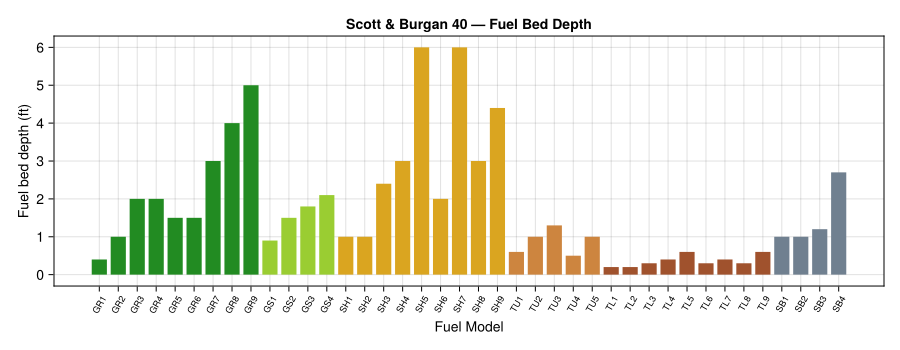

```julia
depths = [f.δ for f in sb40_fuels]

fig = Figure(size=(900, 350))
ax = Axis(fig[1,1],
    xlabel="Fuel Model",
    ylabel="Fuel bed depth (ft)",
    title="Scott & Burgan 40 — Fuel Bed Depth",
    xticks=(1:40, sb40_labels),
    xticklabelrotation=pi/3,
    xticklabelsize=9)
barplot!(ax, 1:40, depths, color=sb_colors)
fig
```

## Rate of Spread

```julia
rate_of_spread(fuel::Rothermel; moisture, wind, slope)
```

Compute the forward rate of fire spread using the Rothermel (1972) model.

#### Arguments

- `fuel::Rothermel` - Fuel model
- `moisture::FuelClasses` - Moisture content per fuel class [fraction, 0–1]. Use 0.0 for unused classes.
- `wind` - Midflame wind speed [km/h]
- `slope` - Terrain slope as rise/run [fraction]

#### Returns

Forward rate of spread at the fire head [m/min].

#### Example

```julia
M = FuelClasses(d1=0.06, d10=0.07, d100=0.08, herb=0.0, wood=0.0)
R = rate_of_spread(SHORT_GRASS, moisture=M, wind=8.0, slope=0.0)
```

### Example

```julia
M = FuelClasses(d1=0.06, d10=0.07, d100=0.08, herb=0.0, wood=0.0)
rate_of_spread(SHORT_GRASS, moisture=M, wind=8.0, slope=0.0)
```

```
31.119112730486354
```

### Effect of Wind Speed

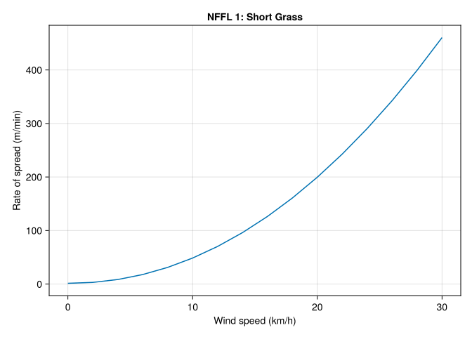

```julia
winds = 0:2:30
rates = [
    rate_of_spread(SHORT_GRASS, moisture=M,
        wind=w, slope=0.0)
    for w in winds
]

fig = Figure()
ax = Axis(fig[1,1],
    xlabel="Wind speed (km/h)",
    ylabel="Rate of spread (m/min)",
    title="NFFL 1: Short Grass")
lines!(ax, collect(winds), rates)
fig
```

### Comparing NFFL Models

Rate of spread at a reference condition (wind = 8 km/h, slope = 0, dead fuel moisture 6–8%):

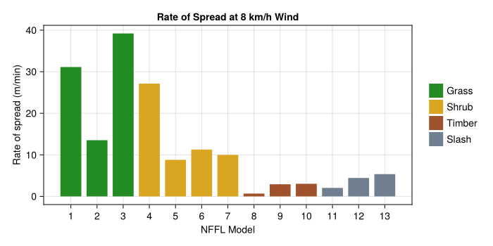

```julia
M_ref = FuelClasses(
    d1=0.06, d10=0.07, d100=0.08,
    herb=0.0, wood=0.0)
M_live = FuelClasses(
    d1=0.06, d10=0.07, d100=0.08,
    herb=0.60, wood=0.90)

all_fuels = [
    SHORT_GRASS, TIMBER_GRASS, TALL_GRASS,
    CHAPARRAL, BRUSH, DORMANT_BRUSH,
    SOUTHERN_ROUGH, CLOSED_TIMBER_LITTER,
    HARDWOOD_LITTER, TIMBER_UNDERSTORY,
    LIGHT_SLASH, MEDIUM_SLASH, HEAVY_SLASH,
]
nffl_labels = string.(1:13)

cat_colors = Dict(
    "Grass" => :forestgreen,
    "Shrub" => :goldenrod,
    "Timber" => :sienna,
    "Slash" => :slategray,
)
categories = [
    "Grass", "Grass", "Grass",
    "Shrub", "Shrub", "Shrub", "Shrub",
    "Timber", "Timber", "Timber",
    "Slash", "Slash", "Slash",
]
colors = [cat_colors[c] for c in categories]

ros = [
    rate_of_spread(f,
        moisture=has_live_fuel(f) ? M_live : M_ref,
        wind=8.0, slope=0.0)
    for f in all_fuels
]

fig = Figure(size=(700, 350))
ax = Axis(fig[1,1],
    xlabel="NFFL Model",
    ylabel="Rate of spread (m/min)",
    title="Rate of Spread at 8 km/h Wind",
    xticks=(1:13, nffl_labels))
barplot!(ax, 1:13, ros, color=colors)

cat_names = ["Grass", "Shrub", "Timber", "Slash"]
elems = [PolyElement(color=cat_colors[c])
    for c in cat_names]
Legend(fig[1,2], elems, cat_names,
    framevisible=false)

fig
```

### Wind Sensitivity by Fuel Category

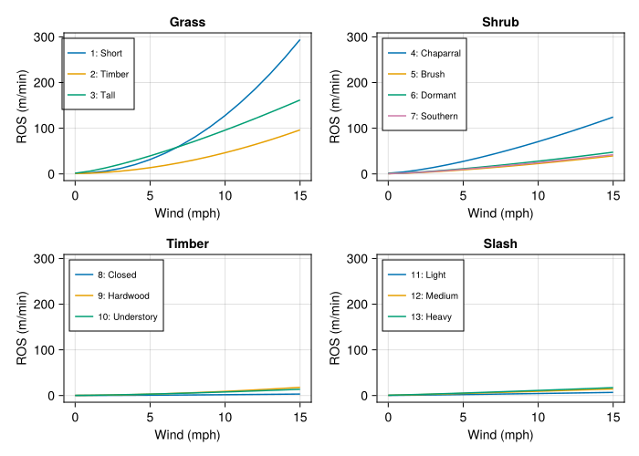

```julia
groups = [
    "Grass" => [
        ("1: Short", SHORT_GRASS),
        ("2: Timber", TIMBER_GRASS),
        ("3: Tall", TALL_GRASS),
    ],
    "Shrub" => [
        ("4: Chaparral", CHAPARRAL),
        ("5: Brush", BRUSH),
        ("6: Dormant", DORMANT_BRUSH),
        ("7: Southern", SOUTHERN_ROUGH),
    ],
    "Timber" => [
        ("8: Closed", CLOSED_TIMBER_LITTER),
        ("9: Hardwood", HARDWOOD_LITTER),
        ("10: Understory", TIMBER_UNDERSTORY),
    ],
    "Slash" => [
        ("11: Light", LIGHT_SLASH),
        ("12: Medium", MEDIUM_SLASH),
        ("13: Heavy", HEAVY_SLASH),
    ],
]

mph = 0:1:15
mph_to_kmh = 1.60934

fig = Figure(size=(700, 500))
axes = []
for (col, (title, fuels)) in enumerate(groups)
    row = col <= 2 ? 1 : 2
    c   = col <= 2 ? col : col - 2
    ax = Axis(fig[row, c],
        xlabel="Wind (mph)",
        ylabel="ROS (m/min)",
        title=title)
    push!(axes, ax)
    for (label, fuel) in fuels
        m = has_live_fuel(fuel) ? M_live : M_ref
        r = [
            rate_of_spread(fuel,
                moisture=m,
                wind=w * mph_to_kmh,
                slope=0.0)
            for w in mph
        ]
        lines!(ax, collect(mph), r, label=label)
    end
    axislegend(ax, position=:lt, labelsize=10)
end
linkyaxes!(axes...)
fig
```

### Fuel Loading by Size Class

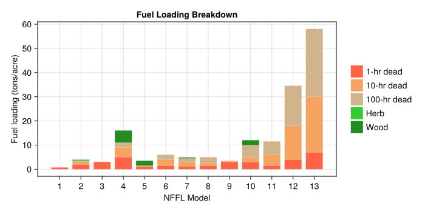

```julia
fig = Figure(size=(700, 350))
ax = Axis(fig[1,1],
    xlabel="NFFL Model",
    ylabel="Fuel loading (tons/acre)",
    title="Fuel Loading Breakdown",
    xticks=(1:13, nffl_labels))

xs = repeat(1:13, 5)
vals = vcat(
    [f.w.d1 for f in all_fuels],
    [f.w.d10 for f in all_fuels],
    [f.w.d100 for f in all_fuels],
    [f.w.herb for f in all_fuels],
    [f.w.wood for f in all_fuels],
)
grp = vcat(
    fill(1, 13), fill(2, 13), fill(3, 13),
    fill(4, 13), fill(5, 13),
)
bar_colors = [
    :tomato, :sandybrown, :tan,
    :limegreen, :forestgreen,
]

barplot!(ax, xs, vals,
    stack=grp,
    color=[bar_colors[g] for g in grp])

bar_labels = [
    "1-hr dead", "10-hr dead", "100-hr dead",
    "Herb", "Wood",
]
elems = [PolyElement(color=c) for c in bar_colors]
Legend(fig[1,2], elems, bar_labels,
    framevisible=false)
fig
```

## References

- Rothermel, R.C. (1972). *A Mathematical Model for Predicting Fire Spread in Wildland Fuels.* Res. Paper INT-115, USDA Forest Service.
- Anderson, H.E. (1982). *Aids to Determining Fuel Models for Estimating Fire Behavior.* Gen. Tech. Rep. INT-122, USDA Forest Service.
- Scott, J.H. & Burgan, R.E. (2005). *Standard Fire Behavior Fuel Models: A Comprehensive Set for Use with Rothermel’s Surface Fire Spread Model.* Gen. Tech. Rep. RMRS-GTR-153, USDA Forest Service.
- Andrews, P.L. (2018). *The Rothermel Surface Fire Spread Model and Associated Developments.* Gen. Tech. Rep. RMRS-GTR-371, USDA Forest Service.